# Sample RNAseq C3G Report

Senthilkumar Kailasam

2020-06-16

# 1 General Information

- Project ID: C3G-IM-427
- Primary Contact: Dr Isabel Molina
- Project Manager: François Levfebvre
- Start Date: Apr 14th, 2020

# 2 Project Information

## 2.1 Objectives:

- Analyze two groups of samples:
  - Nicotiana tobacum and
  - Petunia hybrida
- No. of samples: 12 x2 ( 4 groups; 3 replicates each)
- Groups to compare: all vs all
- Obtain a list of the differentially expressed gene in each development stage and compare it between each of the 4 stages
- Comparison to arabidopsis: Identify homologs of those differentially expressed genes in Arabidopsis.

Note: Letter corresponds to species, T=tobacco and P= Petunia, first number: dev. stage (1, 2, 2.5 or 4), last number: replicate, numbers range from 1 to 6 but only 3 are submitted per stage: T1.1; T1.2; T1.3; T2.1; T2.2; T2.3; T2.5.1; T2.5.2; T2.5.3; T4.2; T4.3; T2.4 P1.3; P1.4; P1.5; P2.1; P2.2; P2.3; P2.5.1; P2.5.3; P2.5.4; P4.1; P4.3; P2.6

# 3 Petunia hybrida RNA seq analysis

## 3.1 Sample Information

## 3.2 Preprocessing and Quality check

### 3.2.1 Reference Genome

FASTA: Petunia_axillaris_v1.6.2_genome.fasta

GFF: Petunia_axillaris_v1.6.2_gene_models.gff

Source : https://solgenomics.net/organism/Petunia_axillaris/genome

### 3.2.2 FASTQC Output of the raw reads

Combined FastQC Report fo All Samples

### 3.2.3 Trimming statistics summary

Trim Table 3.1.

Table 3.1: Retained percentage of reads after trimming.

| Sample | Readset | Raw_Paired_Reads | Surviving_Paired_Reads | Surviving_Paired_Reads_Percent |
| --- | --- | --- | --- | --- |
| P1_1 | P1.3 | 49104904 | 49074208 | 99.9375 |
| P1_2 | P1.4 | 40468259 | 40389662 | 99.8058 |
| P1_3 | P1.5 | 115317816 | 115165886 | 99.8683 |
| P2_1 | P2.1 | 48108314 | 48076484 | 99.9338 |
| P2_2 | P2.2 | 92850237 | 92796438 | 99.9421 |
| P2_3 | P2.3 | 64335189 | 64298391 | 99.9428 |
| P2-5_1 | P2-5.1 | 64007921 | 63968810 | 99.9389 |
| P2-5_2 | P2-5.3 | 81351601 | 81304523 | 99.9421 |
| P2-5_3 | P2-5.4 | 34427231 | 34387421 | 99.8844 |
| P4_1 | P4.1 | 30439163 | 30383387 | 99.8168 |
| P4_2 | P4.3 | 35909099 | 35871462 | 99.8952 |
| P4_3 | P4.6 | 102719186 | 102586945 | 99.8713 |

```
## [1] 35808    13
```

```
##                                        Symbol P1_1 P1_2 P1_3 P2_1 P2_2 P2_3
## Peaxi162Scf00000g00013 Peaxi162Scf00000g00013  330  208  698  321  636  404
## Peaxi162Scf00000g00022 Peaxi162Scf00000g00022 3165 2280 6967 1979 3925 3123
## Peaxi162Scf00000g00029 Peaxi162Scf00000g00029  329  197  879  453  774  664
## Peaxi162Scf00000g00052 Peaxi162Scf00000g00052  337  288  968  337  634  507
## Peaxi162Scf00000g00062 Peaxi162Scf00000g00062    0    0    0    0    0    1
## Peaxi162Scf00000g00067 Peaxi162Scf00000g00067 2653 2265 6219 3286 5260 4397
##                        P2.5_1 P2.5_2 P2.5_3 P4_1 P4_2 P4_3
## Peaxi162Scf00000g00013    460    553    251  230  294  687
## Peaxi162Scf00000g00022   2401   3012   1256 1048 1296 3402
## Peaxi162Scf00000g00029    551    689    230  314  337  809
## Peaxi162Scf00000g00052    412    500    202  192  205  672
## Peaxi162Scf00000g00062      0      0      0    1   10   33
## Peaxi162Scf00000g00067   3246   4512   1724 1282 1079 3337
```

```
##                                        Symbol P1_1 P1_2 P1_3 P2_1 P2_2 P2_3
## Peaxi162Scf00000g00013 Peaxi162Scf00000g00013  330  208  698  321  636  404
## Peaxi162Scf00000g00022 Peaxi162Scf00000g00022 3165 2280 6967 1979 3925 3123
## Peaxi162Scf00000g00029 Peaxi162Scf00000g00029  329  197  879  453  774  664
## Peaxi162Scf00000g00052 Peaxi162Scf00000g00052  337  288  968  337  634  507
## Peaxi162Scf00000g00062 Peaxi162Scf00000g00062    0    0    0    0    0    1
## Peaxi162Scf00000g00067 Peaxi162Scf00000g00067 2653 2265 6219 3286 5260 4397
##                        P2.5_1 P2.5_2 P2.5_3 P4_1 P4_2 P4_3
## Peaxi162Scf00000g00013    460    553    251  230  294  687
## Peaxi162Scf00000g00022   2401   3012   1256 1048 1296 3402
## Peaxi162Scf00000g00029    551    689    230  314  337  809
## Peaxi162Scf00000g00052    412    500    202  192  205  672
## Peaxi162Scf00000g00062      0      0      0    1   10   33
## Peaxi162Scf00000g00067   3246   4512   1724 1282 1079 3337
```

```
##        Group RepID Sample_Name
## P1_1       I     1        P1_1
## P1_2       I     2        P1_2
## P1_3       I     3        P1_3
## P2_1      II     1        P2_1
## P2_2      II     2        P2_2
## P2_3      II     3        P2_3
## P2-5_1   III     1      P2-5_1
## P2-5_2   III     2      P2-5_2
## P2-5_3   III     3      P2-5_3
## P4_1      IV     1        P4_1
## P4_2      IV     2        P4_2
## P4_3      IV     3        P4_3
```

```
##        Group RepID Sample_Name
## P1_1       I     1        P1_1
## P1_2       I     2        P1_2
## P1_3       I     3        P1_3
## P2_1      II     1        P2_1
## P2_2      II     2        P2_2
## P2_3      II     3        P2_3
## P2-5_1   III     1      P2-5_1
## P2-5_2   III     2      P2-5_2
## P2-5_3   III     3      P2-5_3
## P4_1      IV     1        P4_1
## P4_2      IV     2        P4_2
## P4_3      IV     3        P4_3
```

```
## group
##   I  II III  IV
##   3   3   3   3
```

```
##        group lib.size norm.factors
## P1_1       I 38935922            1
## P1_2       I 31297561            1
## P1_3       I 90660395            1
## P2_1      II 38095491            1
## P2_2      II 73600550            1
## P2_3      II 50892984            1
## P2.5_1   III 50117762            1
## P2.5_2   III 63282167            1
## P2.5_3   III 26491405            1
## P4_1      IV 23012271            1
## P4_2      IV 27208672            1
## P4_3      IV 77042425            1
```

```
## [1] 35808    12
```

```
## [1] 35808    12
```

```
## [1] TRUE
```

```
##    GroupI GroupII GroupIII GroupIV
## 1       1       0        0       0
## 2       1       0        0       0
## 3       1       0        0       0
## 4       0       1        0       0
## 5       0       1        0       0
## 6       0       1        0       0
## 7       0       0        1       0
## 8       0       0        1       0
## 9       0       0        1       0
## 10      0       0        0       1
## 11      0       0        0       1
## 12      0       0        0       1
## attr(,"assign")
## [1] 1 1 1 1
## attr(,"contrasts")
## attr(,"contrasts")$Group
## [1] "contr.treatment"
```

```
##           Contrasts
## Levels     PhyII_vsI PhyIII_vsI PhyIV_vsI PhyIII_vsII PhyIV_vsII PhyIV_vsIII
##   GroupI          -1         -1        -1           0          0           0
##   GroupII          1          0         0          -1         -1           0
##   GroupIII         0          1         0           1          0          -1
##   GroupIV          0          0         1           0          1           1
```

```
## numeric(0)
```

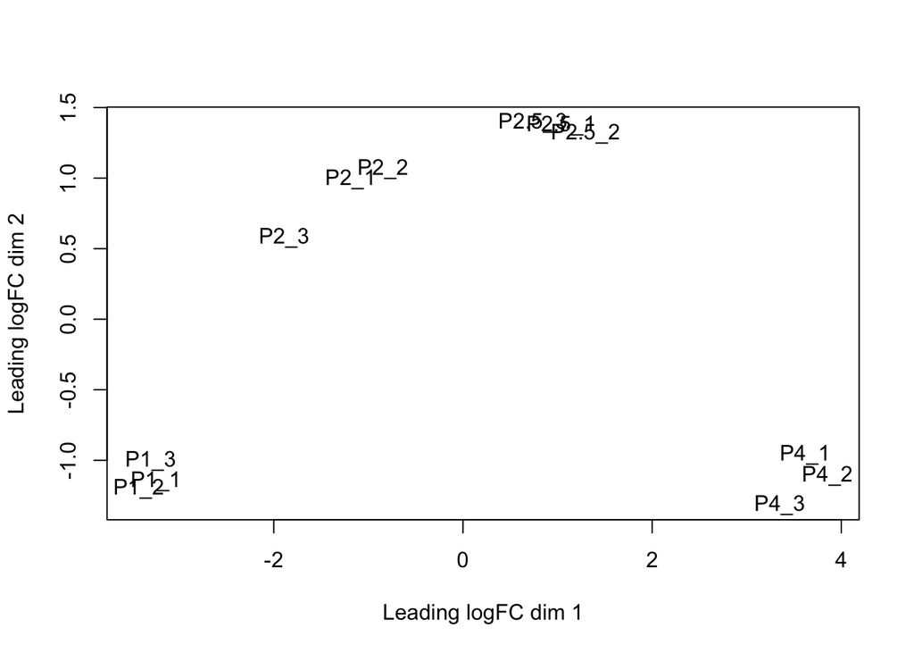

```
## [1] 35808    12
```

```
##        group lib.size norm.factors
## P1_1       I 38935922            1
## P1_2       I 31297561            1
## P1_3       I 90660395            1
## P2_1      II 38095491            1
## P2_2      II 73600550            1
## P2_3      II 50892984            1
## P2.5_1   III 50117762            1
## P2.5_2   III 63282167            1
## P2.5_3   III 26491405            1
## P4_1      IV 23012271            1
## P4_2      IV 27208672            1
## P4_3      IV 77042425            1
```

```
## [1] 35808    12
```

```
## [1] 35808    12
```

```
## keep
## FALSE  TRUE
## 14740 21068
```

```
## [1] 35808    12
```

```
## [1] 21068    12
```

```
##        group lib.size norm.factors
## P1_1       I 38926297    1.1507588
## P1_2       I 31290675    1.1320842
## P1_3       I 90638562    1.1242546
## P2_1      II 38088500    0.9928844
## P2_2      II 73587046    1.0282899
## P2_3      II 50883433    1.0452024
## P2.5_1   III 50109273    0.9763337
## P2.5_2   III 63271222    0.9568366
## P2.5_3   III 26486456    0.9652265
## P4_1      IV 23008028    0.9062420
## P4_2      IV 27203707    0.9014599
## P4_3      IV 77027973    0.8685637
```

```
##                             P1_1      P1_2      P1_3      P2_1      P2_2
## Peaxi162Scf00286g00644 -3.914159 -4.620883 -4.274393 -3.901921 -4.204728
## Peaxi162Scf00035g01816 -4.620883 -4.620883 -4.620883 -3.901921 -2.880790
## Peaxi162Scf00375g00044 -4.620883 -4.620883 -3.995213 -3.901921 -3.618648
## Peaxi162Scf00442g00073 -4.620883 -4.620883 -4.620883 -4.620883 -4.620883
## Peaxi162Scf00064g00738 -4.620883 -3.783877 -3.995213 -4.620883 -4.620883
## Peaxi162Scf00096g01846 -1.416552 -1.607055 -1.610452 -3.066053 -3.882129
##                             P2_3    P2.5_1    P2.5_2    P2.5_3       P4_1
## Peaxi162Scf00286g00644 -4.620883 -4.620883 -4.146958 -3.105910 -1.7301502
## Peaxi162Scf00035g01816 -4.620883 -4.620883 -3.267261 -3.673054 -1.7301502
## Peaxi162Scf00375g00044 -4.620883 -4.620883 -3.505419 -3.673054 -1.7301502
## Peaxi162Scf00442g00073 -4.620883 -4.620883 -3.790819 -4.620883 -1.7301502
## Peaxi162Scf00064g00738 -4.620883 -4.620883 -4.620883 -4.620883 -0.8308469
## Peaxi162Scf00096g01846 -4.051822 -4.620883 -4.146958 -4.620883 -4.6208826
##                              P4_2      P4_3
## Peaxi162Scf00286g00644 -1.5789750 -1.735581
## Peaxi162Scf00035g01816 -1.5789750 -1.866050
## Peaxi162Scf00375g00044 -0.8487185 -1.866050
## Peaxi162Scf00442g00073 -1.2925141 -1.217219
## Peaxi162Scf00064g00738 -1.5789750 -1.217219
## Peaxi162Scf00096g01846 -4.6208826 -4.620883
```

```
## numeric(0)
```

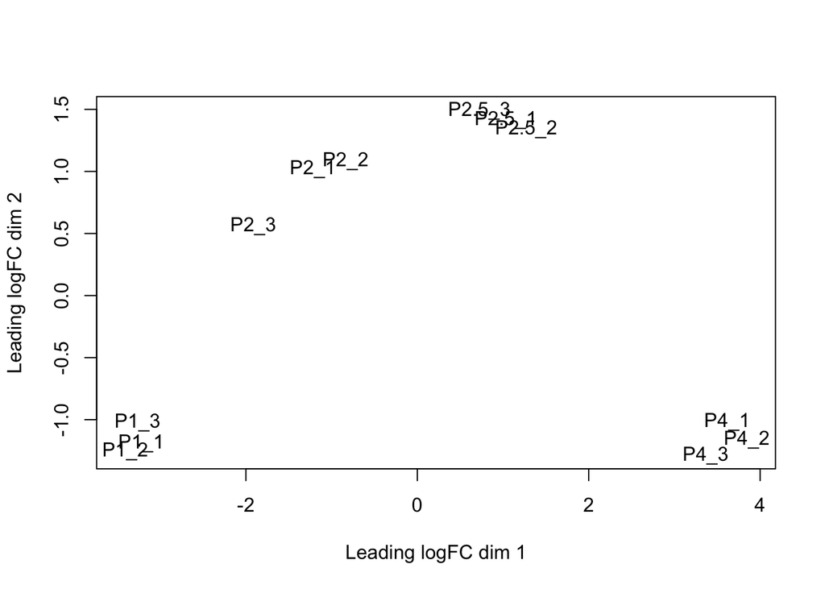

### 3.2.4 PCA sample clustering

(This is done check similarities and dissimilarities between samples in an unsupervised manner)

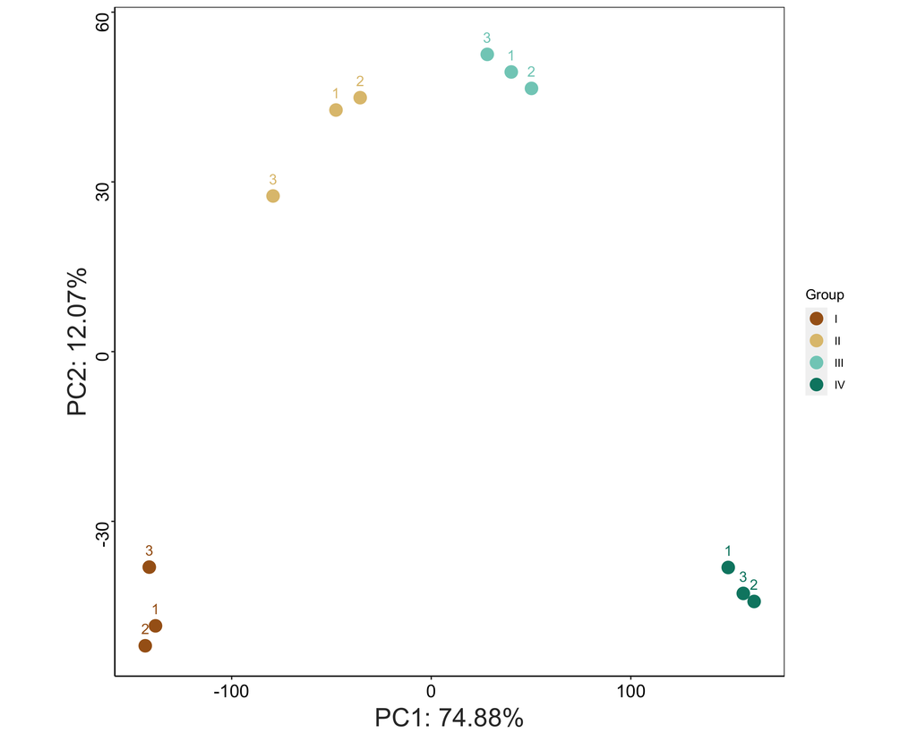

Figure 3.1: PCA based unsupervised clustering of samples

## 3.3 Results

**Developmental stages:**

1. PhyI = 1
2. PhyII = 2
3. PhyIII = 2.5
4. PhyIV = 4

### 3.3.1 Differentially expressed genes summary

Statistical significant difference in gene expression based on

- FOLD CHANGE cut-off > 2
  - FDR(adj.p.value) cut-off < 0.05

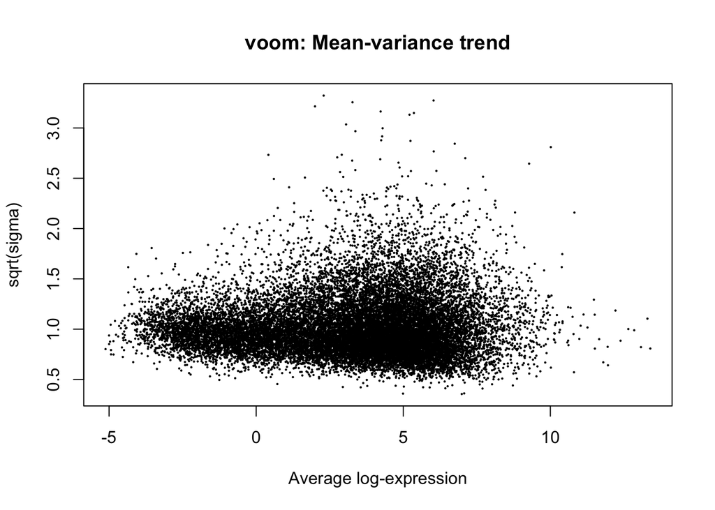

### 3.3.2 Volcano plot

Comparison of all 6 contrasts

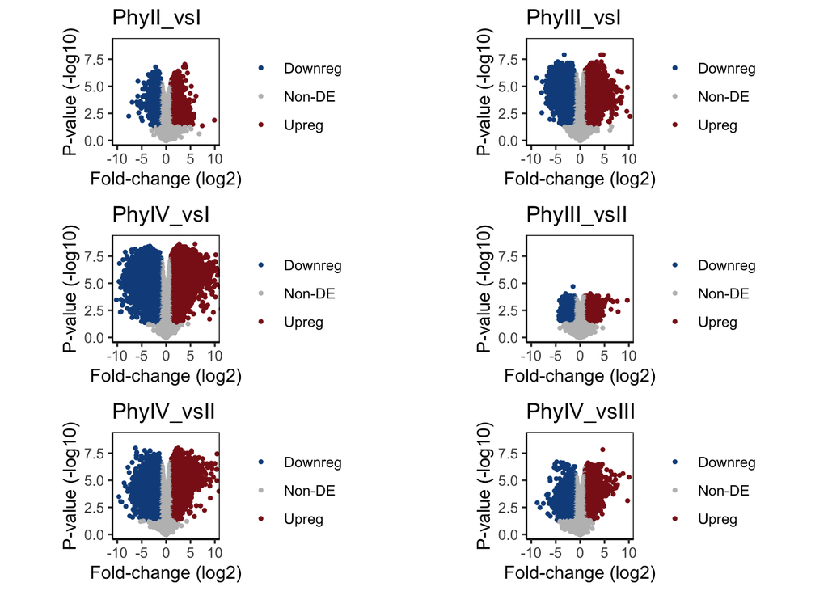

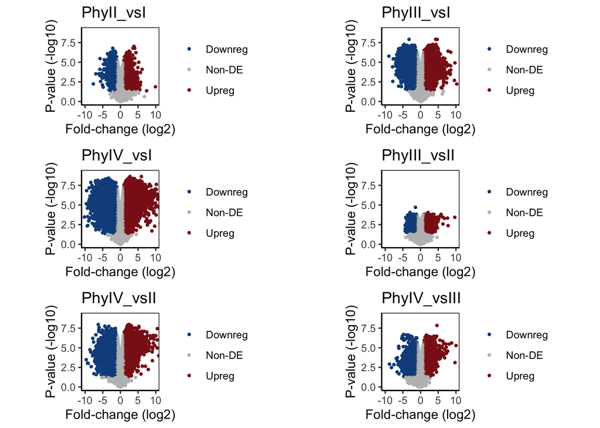

Figure 3.2: Volcano plot

### 3.3.3 Heatmap

```
## [1] 2816
```

```
## [1] 5183
```

```
## [1] 7859
```

```
## [1] 1826
```

```
## [1] 5823
```

```
## [1] 3448
```

#### Average expression heatmap

1. PhyII_vsI

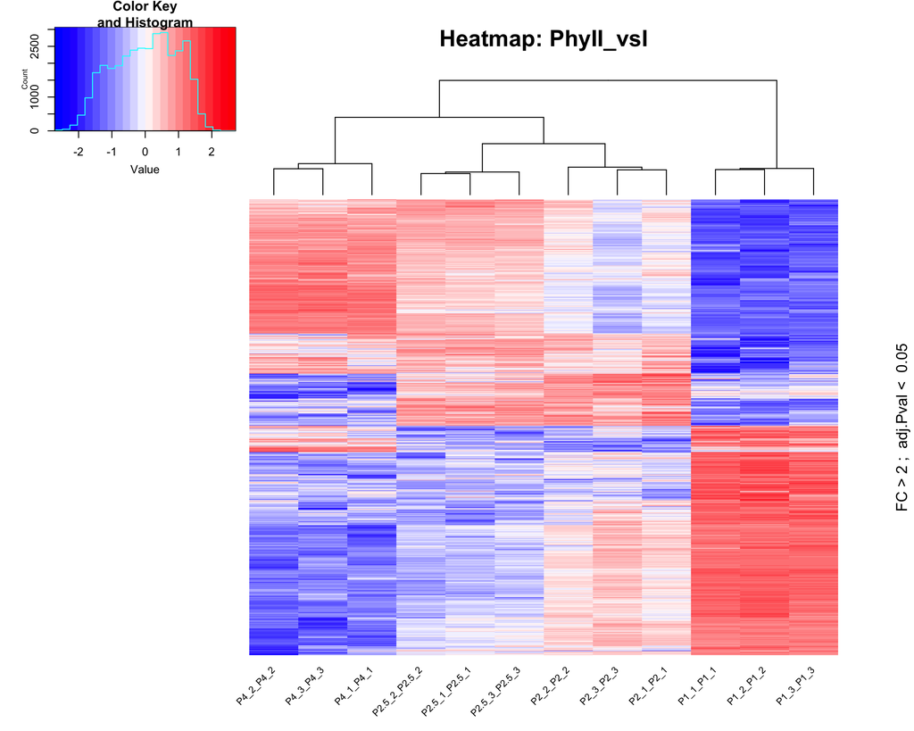

Figure 3.3: Heatmap

b) PhyIII_vsI

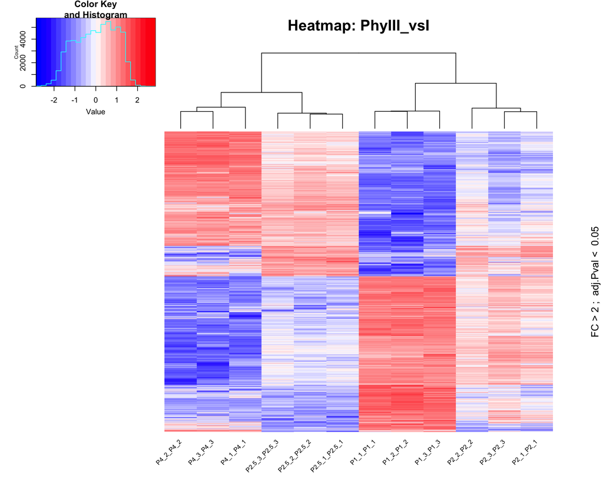

Figure 3.4: Heatmap

c) PhyIV_vsI

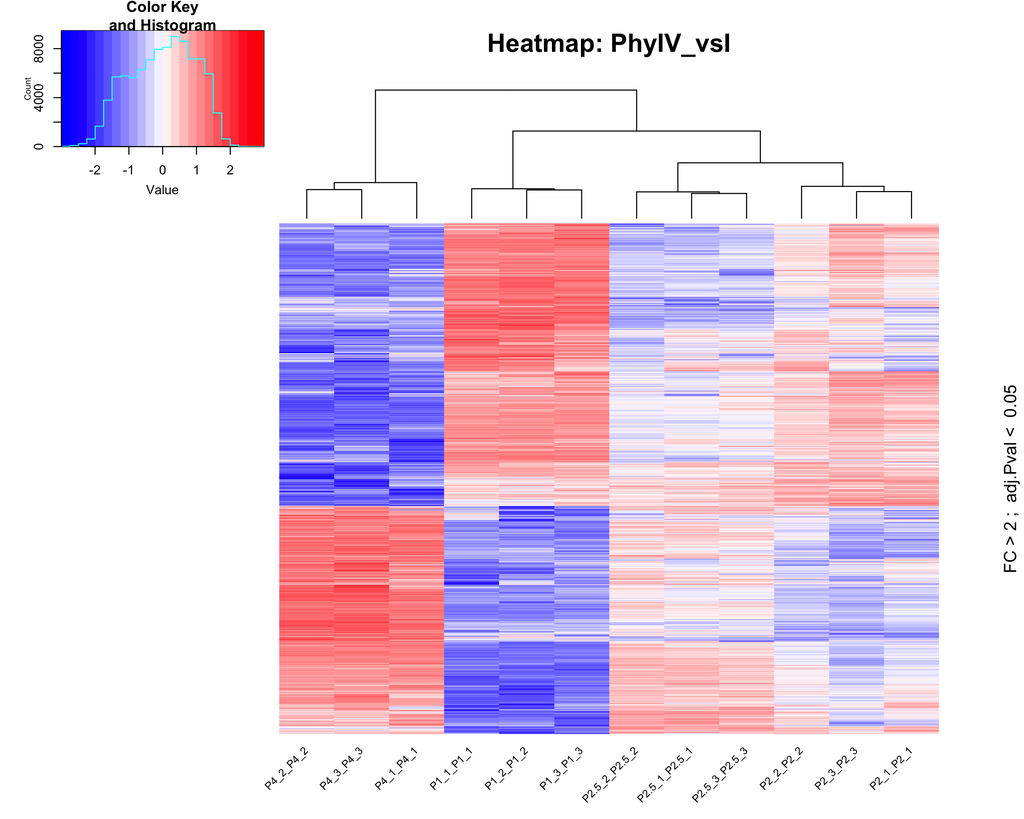

Figure 3.5: Heatmap

d) PhyIII_vsII

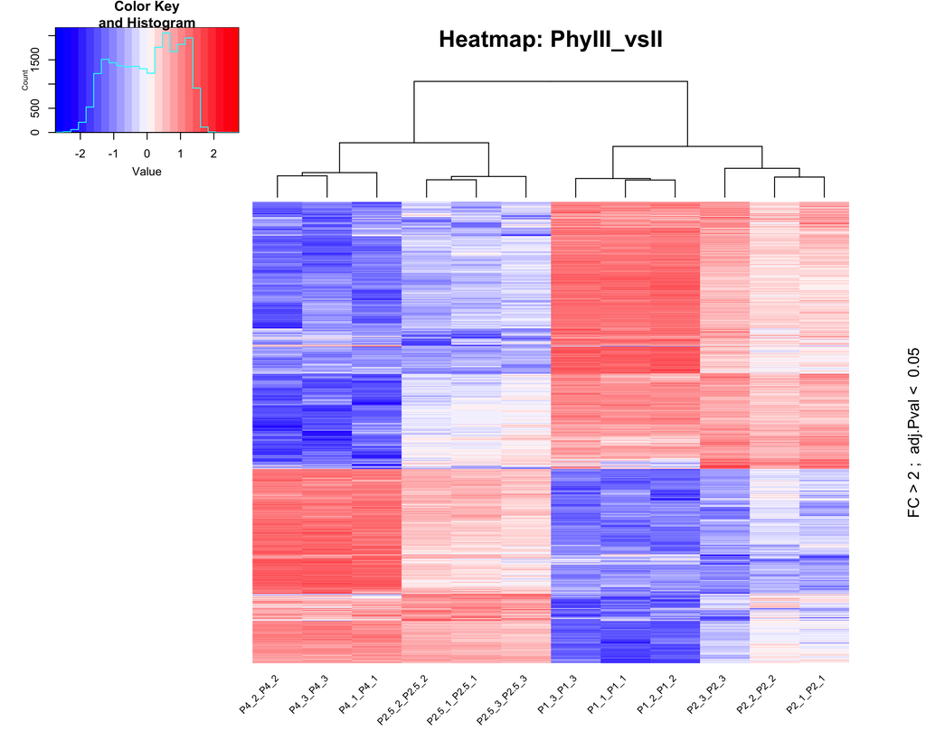

Figure 3.6: Heatmap

e) PhyIV_vsII

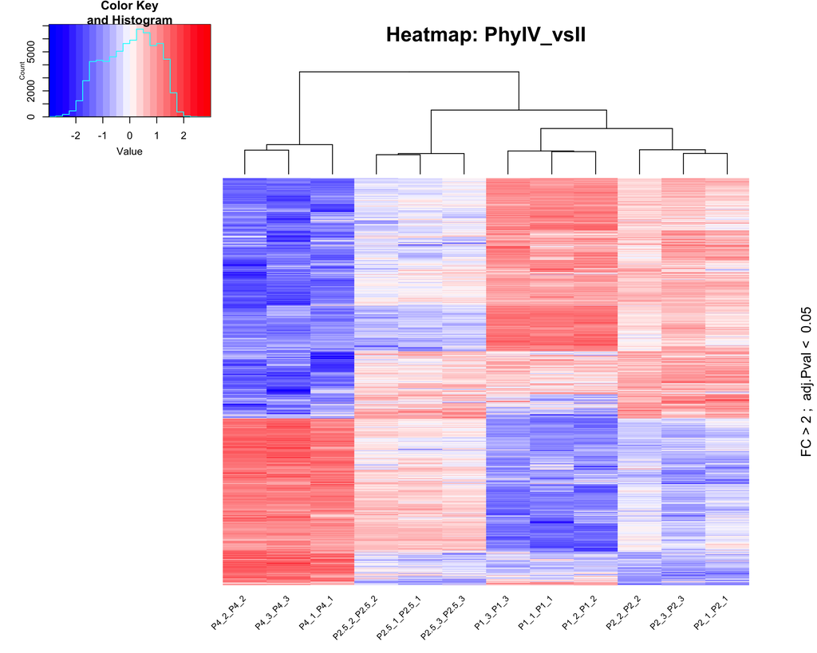

Figure 3.7: Heatmap

f) PhyIV_vsIII

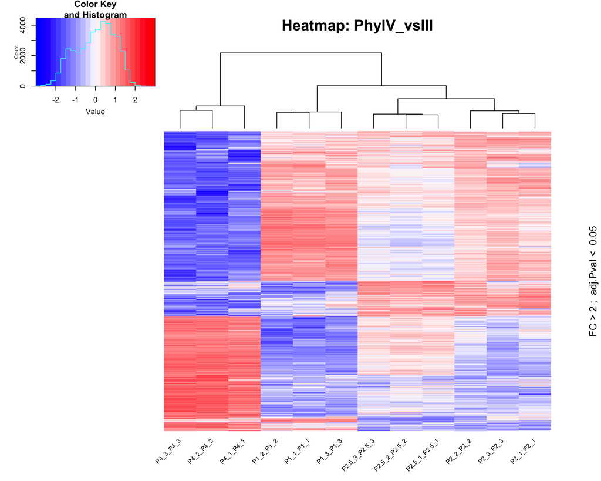

Figure 3.8: Heatmap

#### log CPM based heatmap

1. PhyII_vsI

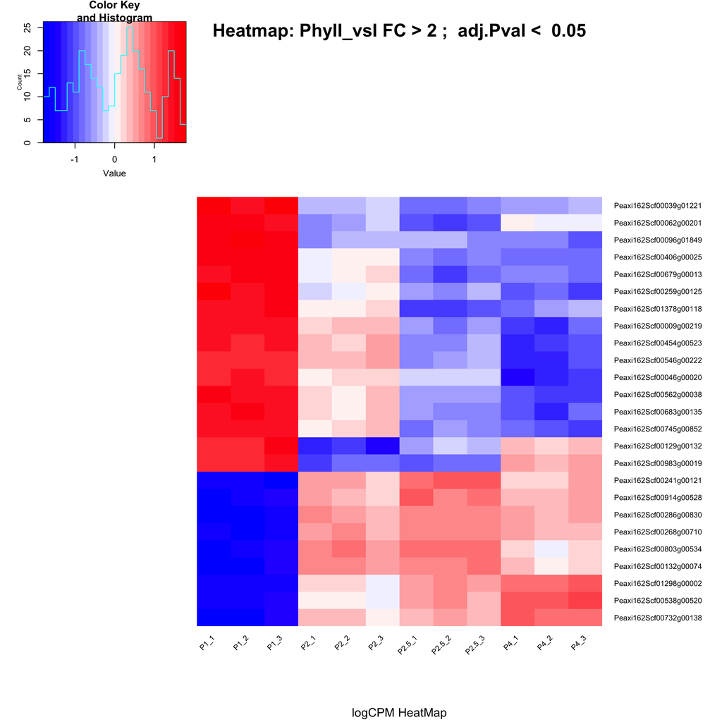

Figure 3.9: Heatmap

b) PhyIII_vsI

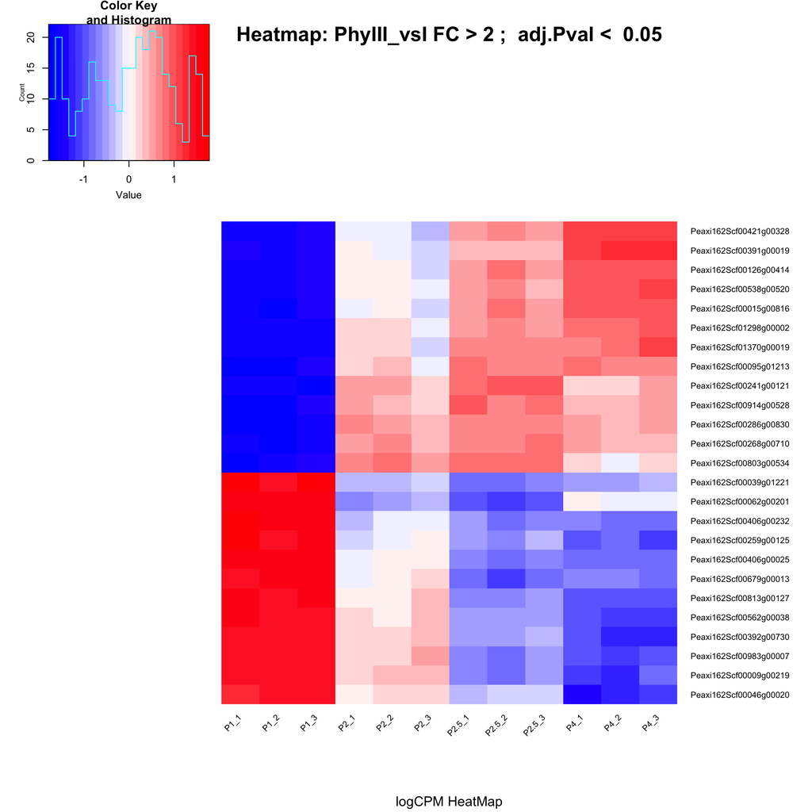

Figure 3.10: Heatmap

c) PhyIV_vsI

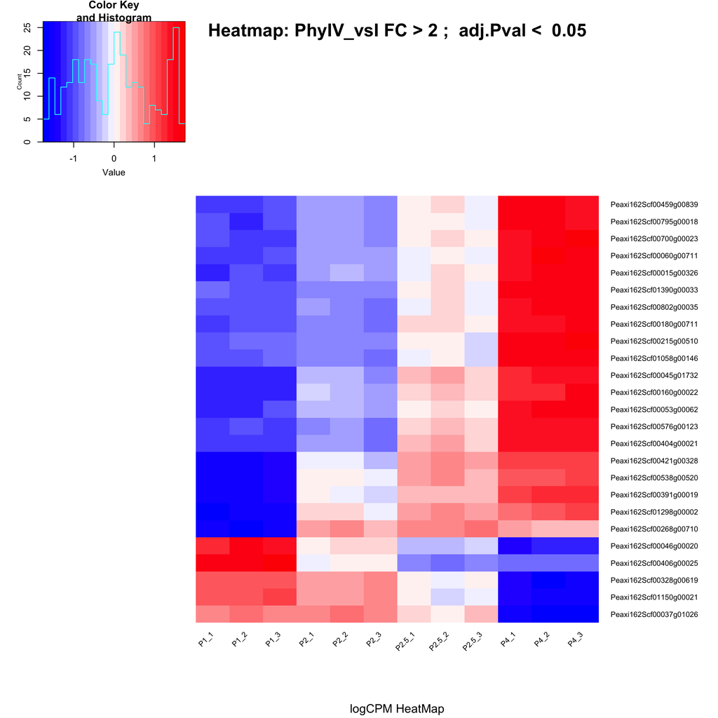

Figure 3.11: Heatmap

d) PhyIII_vsII

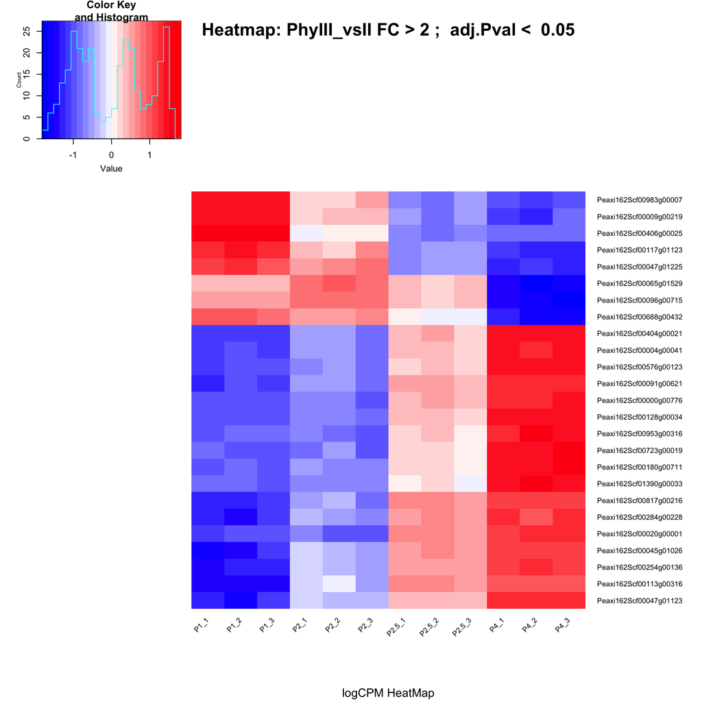

Figure 3.12: Heatmap

e) PhyIV_vsII

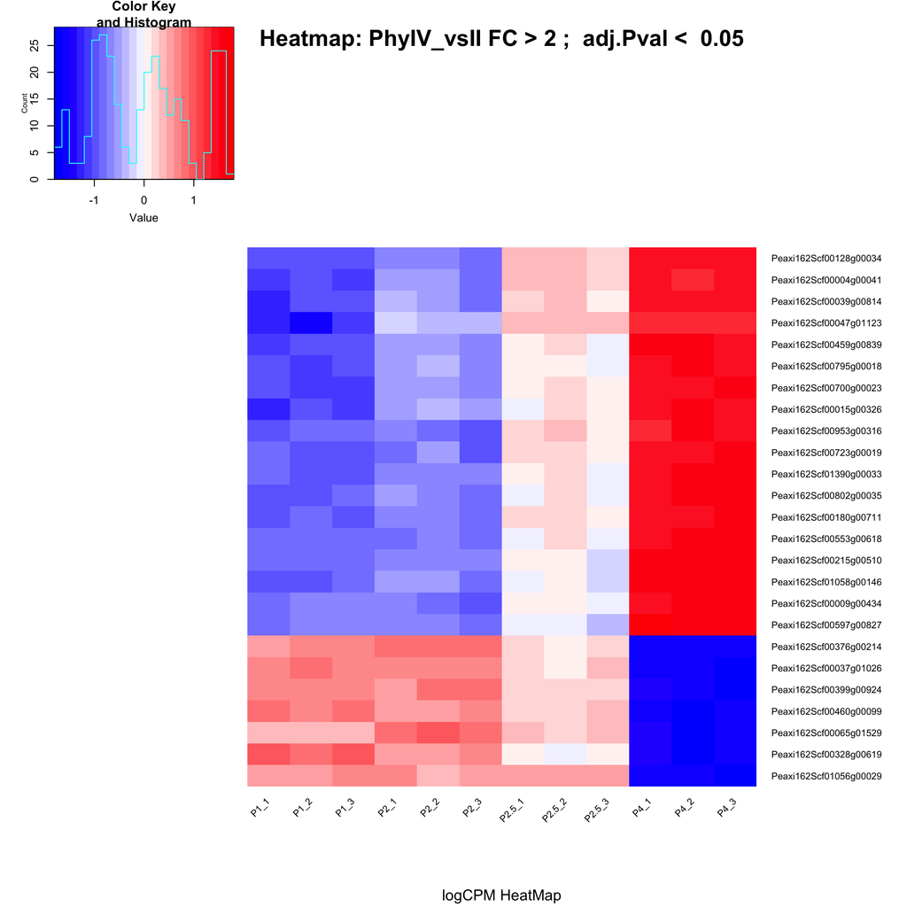

Figure 3.13: Heatmap

f) PhyIV_vsIII

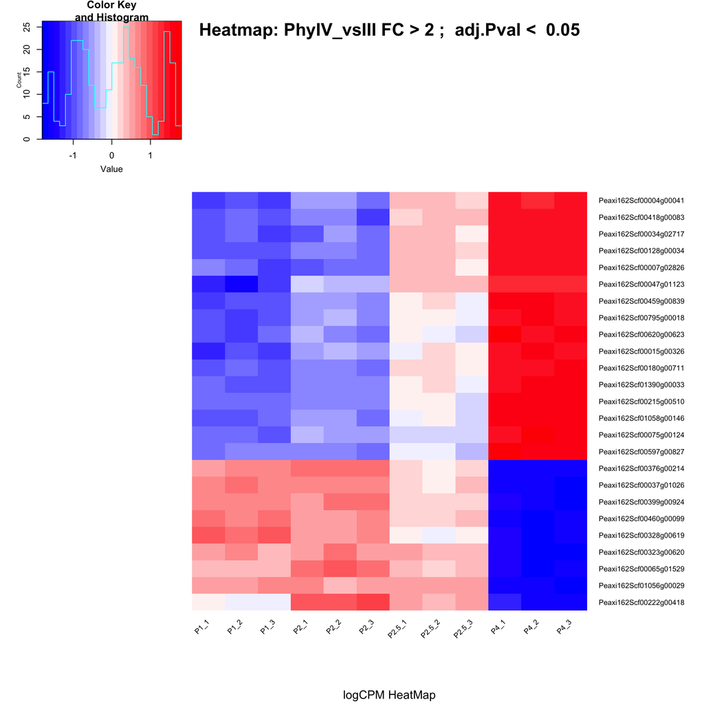

Figure 3.14: Heatmap

### 3.3.4 GO enrichment analysis

1. PhyII_vsI, PhyIII_vsI and PhyIV_vsI

```
##  [1] cell cycle
##  [2] cell cycle process
##  [3] cell division
##  [4] cellular metabolic process
##  [5] cellular process
##  [6] cellular response to chemical stimulus
##  [7] DNA replication
##  [8] DNA-dependent DNA replication
##  [9] meiotic cell cycle
## [10] meiotic cell cycle process
## [11] meiotic nuclear division
## [12] metabolic process
## [13] mitotic cell cycle
## [14] mitotic cell cycle process
## [15] nuclear division
```

[output cut: 24 more lines]

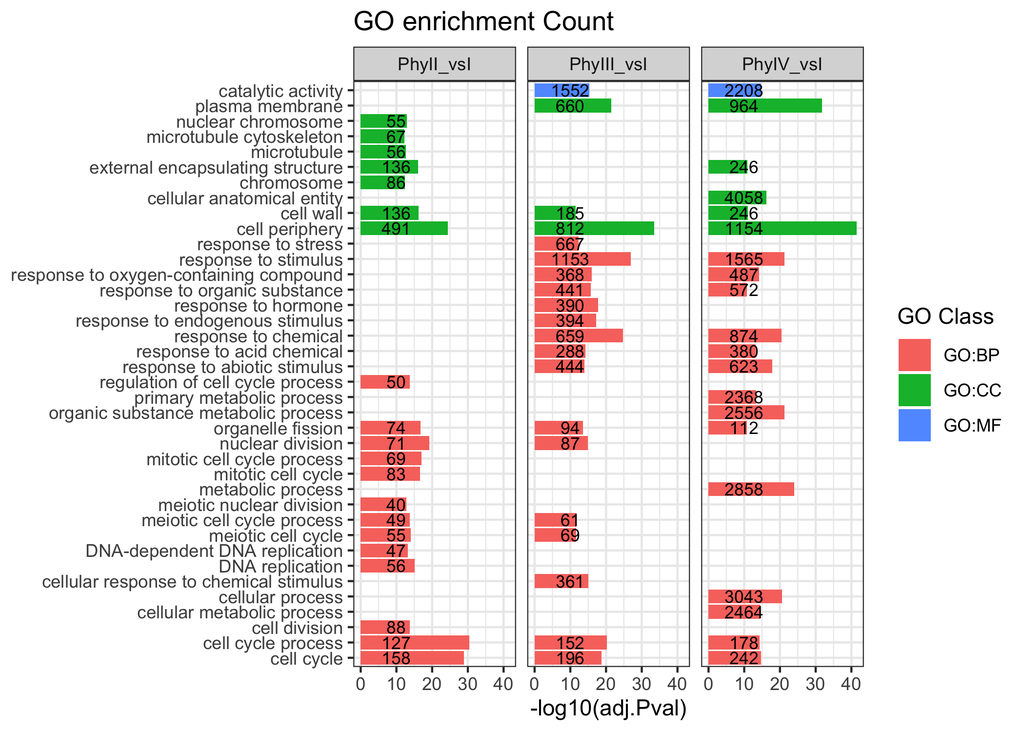

Figure 3.15: GO enrichment: Comparison between 3 group

b) PhyIII_vsII, PhyIV_vsII and PhyIV_vsIII

```
##  [1] cell cycle
##  [2] cell cycle process
##  [3] cell division
##  [4] cell wall organization or biogenesis
##  [5] cellular response to chemical stimulus
##  [6] lipid metabolic process
##  [7] metabolic process
##  [8] mitotic cell cycle process
##  [9] nuclear division
## [10] organelle fission
## [11] phenylpropanoid biosynthetic process
## [12] phenylpropanoid metabolic process
## [13] response to abiotic stimulus
## [14] response to acid chemical
## [15] response to chemical
```

[output cut: 16 more lines]

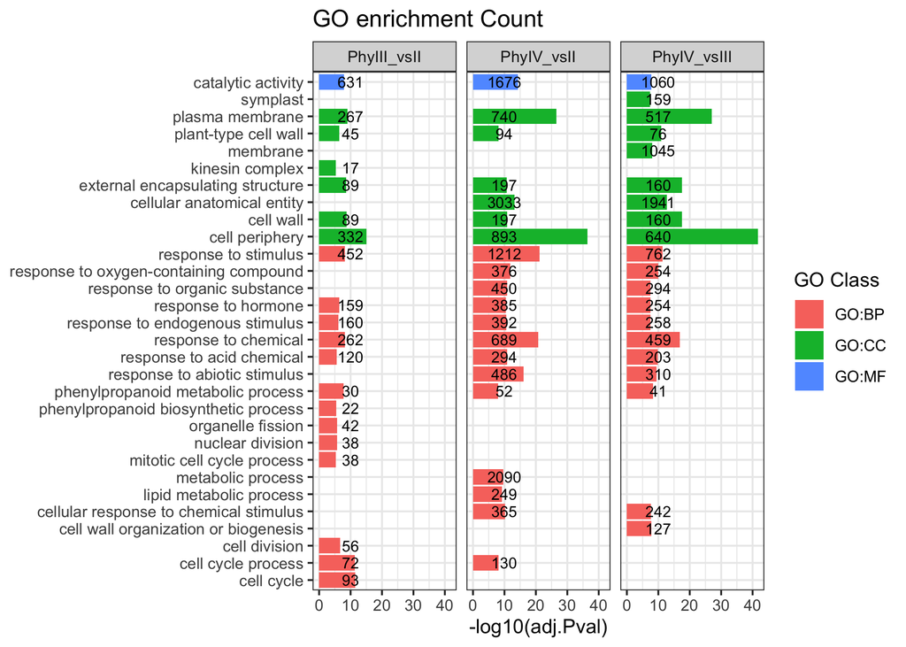

Figure 3.16: GO enrichment: Comparison between 3 group

### 3.3.5 KEGG pathway analysis

1. PhyII_vsI, PhyIII_vsI and PhyIV_vsI

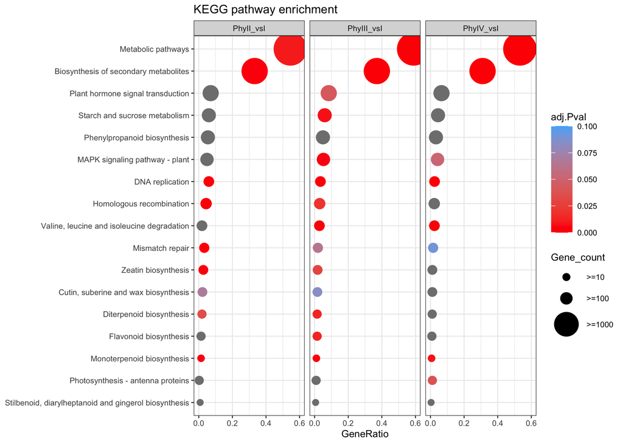

Figure 3.17: KEGG pathway analysis: Comparison between 3 group

b) PhyIII_vsII, PhyIV_vsII and PhyIV_vsIII

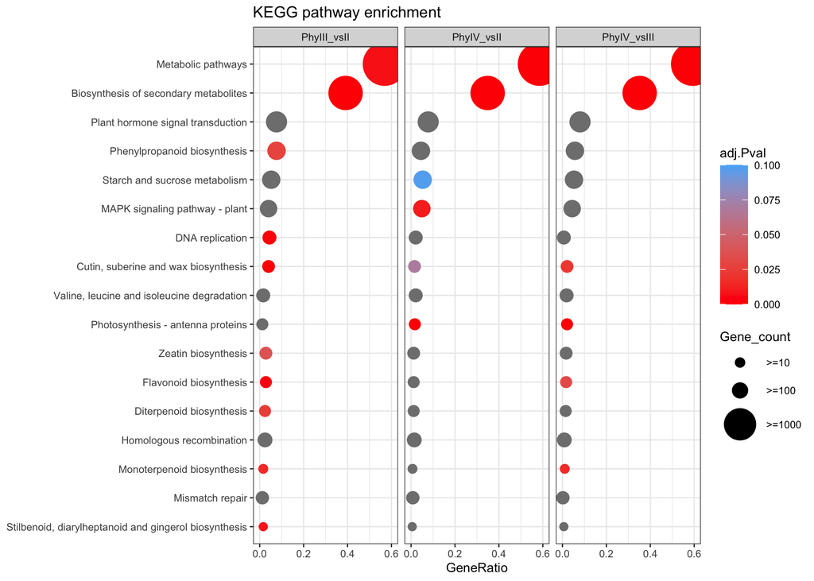

Figure 3.18: KEGG pathway analysis: Comparison between 3 group

### 3.3.6 DEG Tables for each contrast

1. List of Tables with LogFC, pvalue and FDR value.
   - Table_deg_PhyIII_vsI.csv
   - Table_deg_PhyIII_vsII.csv
   - Table_deg_PhyII_vsI.csv
   - Table_deg_PhyIV_vsI.csv
   - Table_deg_PhyIV_vsII.csv
   - Table_deg_PhyIV_vsIII.csv
2. List of Master Tables with LogFC, pvalue and FDR value and Functional_annotation, TAIR10 homolog ID, GO term etc.
   - Table_PhyIII_vsII__DEG_masterfile.csv
   - Table_PhyII_vsI__DEG_masterfile.csv
   - Table_PhyIV_vsII__DEG_masterfile.csv
   - Table_PhyIII_vsI__DEG_masterfile.csv
   - Table_PhyIV_vsIII__DEG_masterfile.csv
   - Table_PhyIV_vsI__DEG_masterfile.csv

# 4 Methodology

### 4.0.1 Differential expression analysis:

Adaptor sequences and low-quality score containing bases (Phred score < 30) were trimmed from reads using Trimmomatic (Bolger, Lohse, and Usadel 2014). The resulting reads were aligned to the Petunia axillaris and Nicotiana tabacum genome, using STAR (Dobin et al 2012). Read counts are obtained using HTSeq (Anders et al 2015). The R package limma (Ritchie et al 2015) was used to identify differences in expression levels between the groups. Nominal p-values were corrected for multiple testing using the Benjamini-Hochberg method. Arabidopsis homologs for each gene was obtained using BLASTP (Camacho et al, 2008)

### 4.0.2 Gene Ontology (GO) and KEGG enrichment analysis:

We considered all the genes which were differentially expressed. Functional enrichment analyses (Gene Ontology and KEGGs) were performed with gProfileR (Reimand et al 2009). Enrichment p-values were based on a hypergeometric test using the set of known human genes as background. The default “g:SCS method “ was applied for multiple testing correction. It corresponds to an experiment-wide threshold of a=0.05, i.e. at least 95% of matches above threshold are statistically significant.

#### Reference:

1. Reimand J, Arak T, Adler P, Kolberg L, Reisberg S, Peterson H, Vilo J. g:Profiler-a web server for functional interpretation of gene lists (2016 update). Nucleic Acids Res. 2016 Jul 8;44(W1):W83-9. doi: 10.1093/nar/gkw199. Epub 2016 Apr 20.
2. Bolger, A.M., Lohse, M. and Usadel, B., 2014. Trimmomatic: a flexible trimmer for Illumina sequence data. Bioinformatics, 30(15), pp.2114-2120.
3. Anders, S., Pyl, P.T. and Huber, W., 2015. HTSeq—a Python framework to work with high-throughput sequencing data. Bioinformatics, 31(2), pp.166-169.
4. Dobin, A., Davis, C.A., Schlesinger, F., Drenkow, J., Zaleski, C., Jha, S., Batut, P., Chaisson, M. and Gingeras, T.R., 2013. STAR: ultrafast universal RNA-seq aligner. Bioinformatics, 29(1), pp.15-21.
5. Ritchie, M.E., Phipson, B., Wu, D., Hu, Y., Law, C.W., Shi, W. and Smyth, G.K., 2015. limma powers differential expression analyses for RNA-sequencing and microarray studies. Nucleic acids research, 43(7), pp.e47-e47.
6. Camacho C., Coulouris G., Avagyan V., Ma N., Papadopoulos J., Bealer K., & Madden T.L. (2008) “BLAST+: architecture and applications.” BMC Bioinformatics 10:421